# Notebook

Last modified

Sep, 2025

18

10:58:32 AM

SIM Security Breach: Unauthorized Access & OTP Exposure

## Sequence of Connected Events

## 7:36 AM (17th Sep, 2025)

On the morning of 17th September, I received an OTP on Telegram, indicating that someone had attempted to log in using my number. I initially dismissed it, assuming it was an accidental entry of my number by someone else.

[figure not shown]

## 8:45 AM (17th Sep, 2025)

At 8:45 AM, I received another OTP via SMS for Tata Neu (an online shopping platform that also includes services like BigBasket). This raised my concern about unusual activity, but I did not take immediate action as I felt there was little I could do other than wait and monitor the situation.

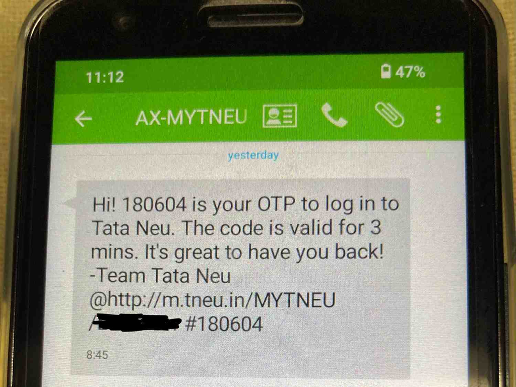

## 11:02 (17th Sep, 2025)

At 11:02 AM, I received a message that significantly escalated the situation. It stated that 55.83 NeuCoins (in-app reward points used for discounts) had been spent from my account.

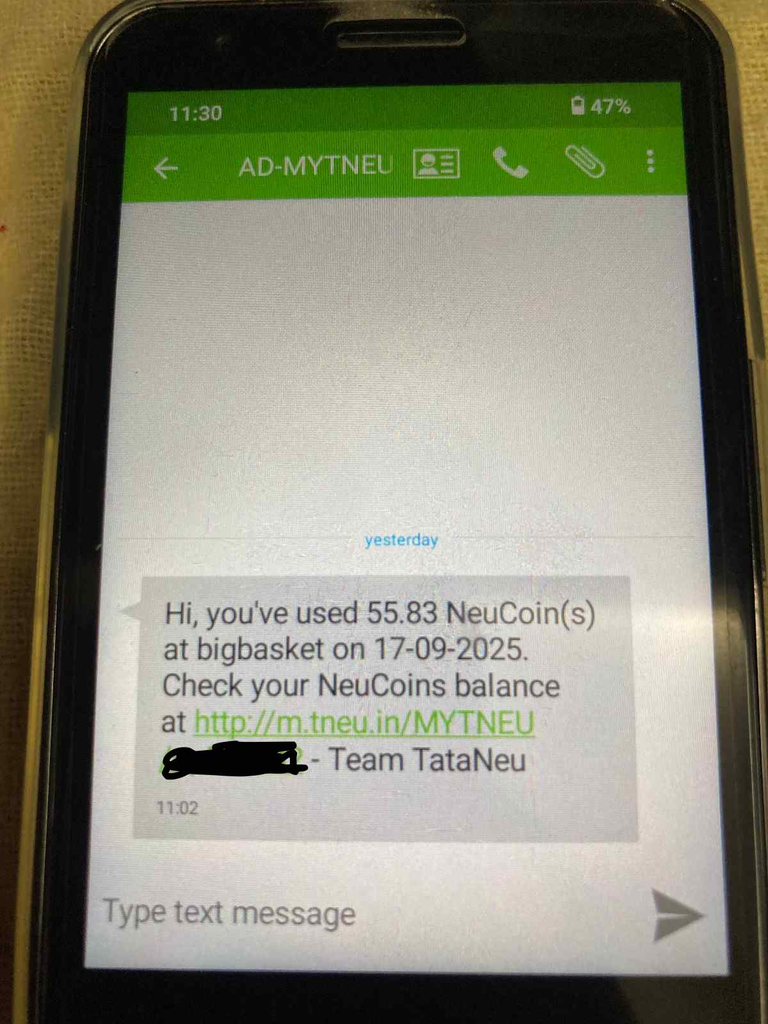

## 11:30 (17th Sep, 2025)

I was initially unaware of the full extent of the issue. To investigate, I downloaded the Tata Neu app and logged into my account, where I discovered that an order had been placed from Visakhapatnam, a location where I have no relatives or friends who could have used my credentials.

At this stage, I was uncertain whether the issue stemmed from the app itself or from something more serious. I contacted Tata Neu customer support to report the matter. Their immediate response was to log me out from all devices and prevent any return orders from being placed. I requested to be connected with the person who had placed the order, but they declined due to privacy policies. I then asked if I could speak with the delivery person to understand how the recipient was contacted, since my own number was listed in the app. If the delivery call had been directed to the number shown in the app, I should have received it unless someone had unauthorized access to my SIM and was able to intercept or redirect calls. The support team informed me that the delivery person had successfully contacted the recipient and completed the delivery. This revelation left me shocked and without answers, as the only information I had was the recipient’s name and address from the invoice.

It is worth noting that, by this time, the app displayed my contact number, which created significant confusion. If the app was showing my number, how was the delivery person’s call being received by someone else?

## 12:15 (17th Sep, 2025)

At this point, I began receiving multiple OTPs for Tata Neu. My assumption is that when customer support logged me out from all devices, the recipient was also logged out. By coincidence, I logged back into the app at the same time as the other party. It appears he had already changed the registered contact number to his own, likely in an attempt to place a return order. In that moment, I noticed that the contact number displayed in the app was no longer mine, and the associated email address was also fraudulent. I captured a screenshot of this evidence, with the recipient’s number blurred out for privacy reasons.

The person managed to obtain a product worth ₹760 for free by using my account’s wallet balance, a new-user promo code, and some Tata Neu reward points. In fact, had the NeuCoins not been used, I would likely not have received any notification that prompted me to investigate further.

[figure not shown]

## 12:27 (17th Sep, 2025)

With this lead in hand, I called the individual to understand how he had managed to access my account. He explained that he had logged in using his own contact number and was surprised to find money already available in the wallet, which he then used to place the order. I did not cross question much or ask for giving me my money back. My conversation with him led me to believe that a technical glitch in the app might have caused the mix-up, which left me feeling somewhat reassured at the time.

## 14:32 (17 Sept, 2025)

Somebody booked *OLA Cab* using my account. At this point, I knew that my SIM card has been compromised but I had no clue of who are involved and what are they able to access.

[figure not shown]

I then called the Tata Neu guy again and pressed him to tell me the truth, mentioning that I intended to file a police complaint. At that point, he revealed that he had obtained my OTP through a website called [Numera SMS](https://numerasms.com/), which was somehow able to capture and sell it to him. I will not go into the specifics of how such sites operate.

I contacted my network provider but the most they could do was log me out from their app on all devices and enable DND (Do Not Disturb) mode. I was then advised to monitor my account for any further suspicious activity.

## Between 7-8 AM (18 Sept, 2025)

I received a pop-up notification from OLA stating:

**WELCOME TO MADAGASCAR**  
bla, bla, bla…

I have raised concern to the OLA support team, waiting for them to respond.

## Queries Yet To Be Resolved

1. What information would an attacker need about your SIM card to compromise it?
2. If a SIM card is compromised, what data or services can an attacker access?
3. How could someone obtain this SIM information without your knowledge?
4. In my specific case, how did the operator manage to access this information?
5. What actions can you take if your SIM is compromised?
6. Would porting your number to a different service provider resolve the issue, or could the problem be more deeply rooted?
7. How can such website that sell your OTPs exists?

## Potential Source

On 8th September 2025, I switched my handset from an iPhone SE to a DOOV R17. It is possible that this device leaked the SIM card information required to compromise my account.

[figure not shown]